# Portfolio Hedging

Alexey Ivanov

2019-10-20

### Пакеты

```r
library( QuantTools ) # Market data loading
library( data.table ) # Library for data management
library( derivmkts )  # Library for option pricing
library( corrplot  )  # Corr ploting
```

### Функции

Функция для расчета статистики

```r
calc_perfomance_stat = function( returns, convert_to_return = F ){

  returns = returns[ !is.na( returns ) ]
  pnl = cumprod( returns + 1 )

  summary = data.table(
    pnl     = prod( returns + 1 ) - 1,
    max_dd  = min( pnl / cummax( pnl ) - 1 ) * 100,
    mean_dd = mean( pnl / cummax( pnl ) - 1 ) * 100,
    sharpe  = mean( returns ) / sd( returns ) * sqrt(252)
  )

  round( summary, 3 )

}
```

### Загрузка данных

```r
# Get market data
symbols = data.table( symbol = c( "AAPL", "MCD", "JPM" ) )
market_data = symbols[, get_yahoo_data( symbol, from = "2012-01-02", to = "2020-01-01" ), by = symbol ]
market_data = market_data[, .(symbol, date, close)]

# calc returns
market_data[, return := close/ shift( close, fill = close[1] ) - 1 , by = symbol ]

# stock results
market_data[, calc_perfomance_stat( return ), symbol][order(pnl)]
```

```
##    symbol   pnl  max_dd mean_dd sharpe
## 1:    MCD 1.678 -16.344  -4.592  0.896
## 2:    JPM 3.299 -32.563  -5.686  0.975
## 3:   AAPL 3.611 -43.797 -12.464  0.892
```

Объединяем бумаги в портфель с равными весами

```r
# covert from narrow data to wide table
portfolio = dcast( market_data, date ~ symbol, value.var = "return" )

# let's check correlation
round( cor( portfolio[,-1] ), 3 )
```

```
##       AAPL   JPM   MCD
## AAPL 1.000 0.338 0.257
## JPM  0.338 1.000 0.316
## MCD  0.257 0.316 1.000
```

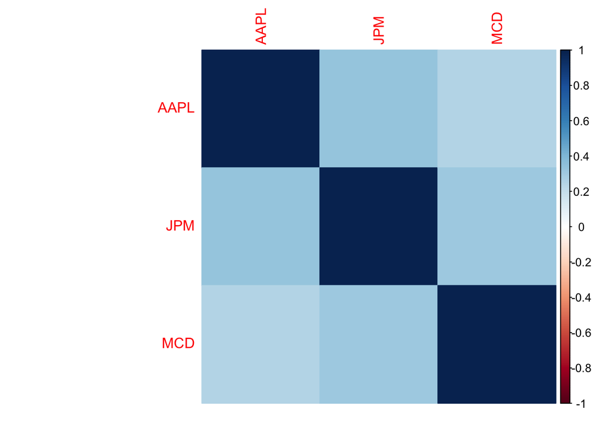

```r
corrplot( cor( portfolio[,-1] ), method = "color"  )
```

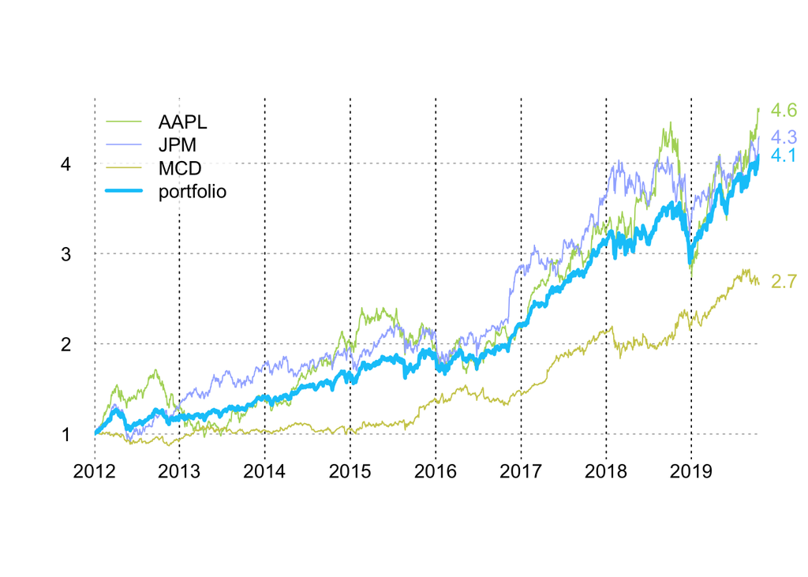

```r
# calc portfolio
portfolio[, portfolio := rowMeans( .SD[,-1] )]
portfolio = data.table( portfolio[, 1], portfolio[, lapply(.SD[,-1], function(x) cumprod( x + 1 ) ) ] )

plot_dts( portfolio )$lines( lwd = c(1,1,1,3) )
```

```r
# portfolio result
portfolio[, calc_perfomance_stat( (portfolio/shift(portfolio)-1) )]
```

```
##      pnl  max_dd mean_dd sharpe
## 1: 3.088 -18.869  -3.216  1.246
```

### Хеджирование для одного актива

Возьмем Apple из уже готовых данных

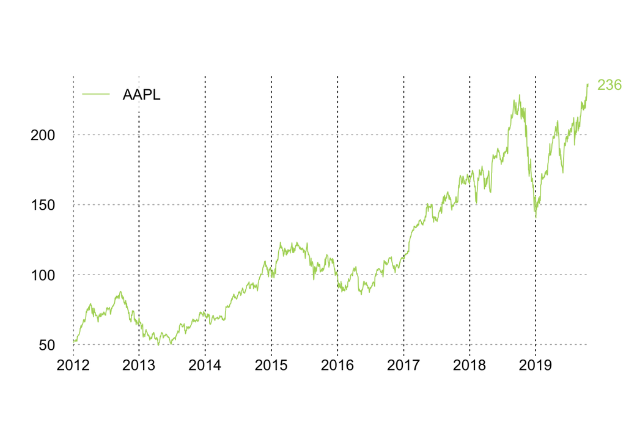

```r
stock = market_data[symbol == "AAPL"]
plot_dts( stock[, .(date, AAPL = close)] )
```

Для верной оценки стоимости опциона нужна так называема **Implied Volatility** ( **IV** или подразумеваемая волатильность).  
Как правило, IV сложно достать в открытом доступе, но простое стандартное отклонение может быть хорошим приближением.

В данном примере мы будем использовать годовые опционы поэтому посчитаем sd за год

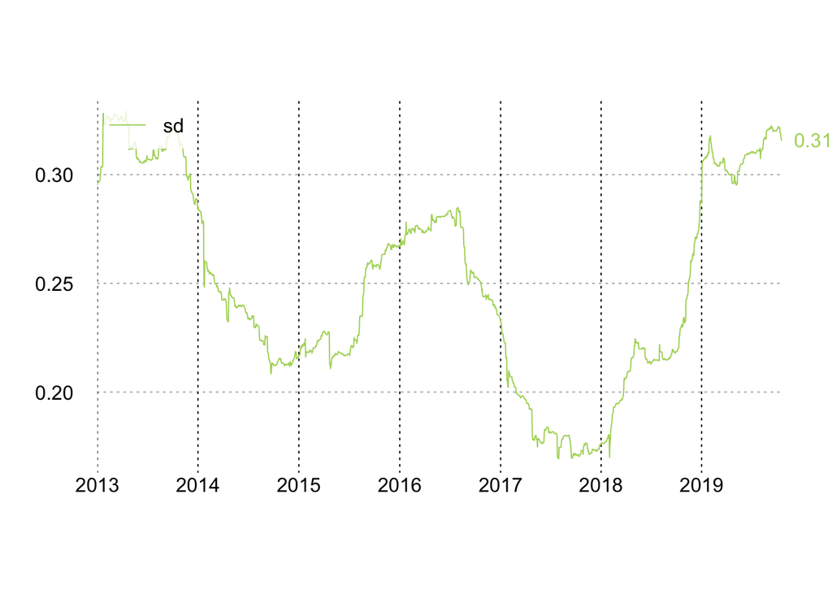

```r
stock[, sd := roll_sd( return, 252 ) * sqrt(252)]
stock = stock[!is.na(sd)] # cut NA

plot_dts( stock[, .(date, sd) ] )
```

Для примера возьмем 2016 год

Расчитаем ценовую динамику опциона пут.  
В качестве страйка возмет цену актива в начале года. Волотильность - sd, t - расчитаем в долях к году.

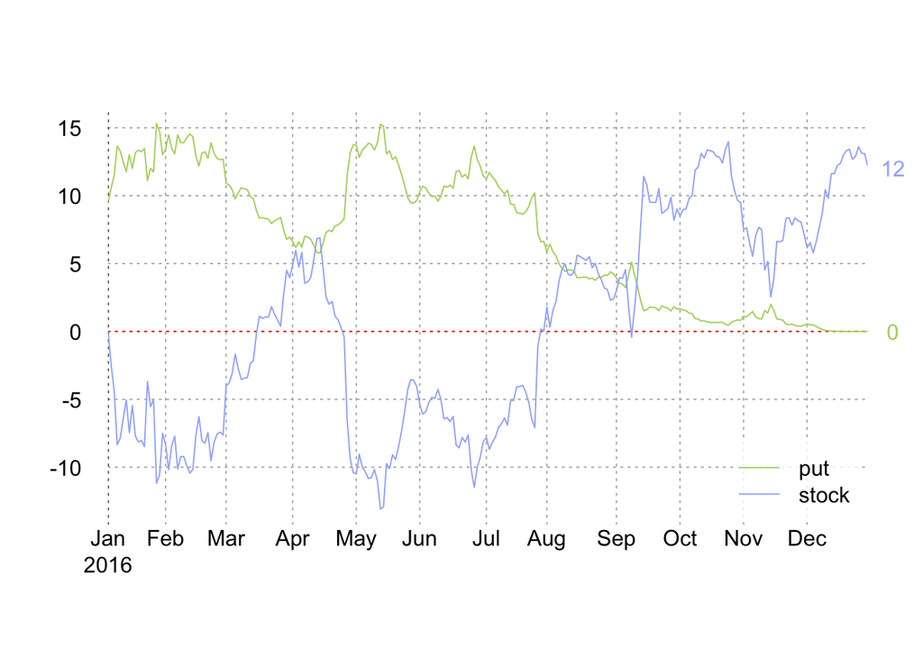

```r
stock_option = stock[ year(date) == 2016][, .(date, close, return,  sd) ]

# calc time to maturity
stock_option[, t := as.numeric(date[.N] - date)/365 ]

# calc option price
stock_option[, put := bsput(close, as.integer(close[1]), sd, 0.01, t, d = 0 ) ]

plot_dts( stock_option[, .(date, put, stock = close - close[1])] )$style(
  legend = list( position = 'bottomright') )
```

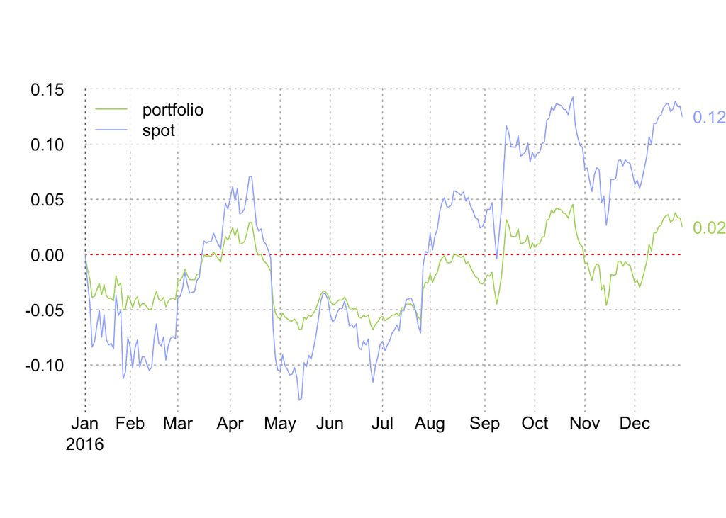

```r
# calc portfolio pnl
stock_option[, portfolio := (close + put ) / (put[1] + close[1]) ]
plot_dts( stock_option[, .(date, portfolio =  portfolio- 1, spot = cumprod(return+1)-1) ] )
```

```r
# calc portfolio returns
stock_option[, portfolio_ret := portfolio / shift(portfolio, 1) - 1]

stock_option[, calc_perfomance_stat( portfolio_ret )]
```

```
##      pnl max_dd mean_dd sharpe
## 1: 0.025 -9.432  -4.058  0.264
```

```r
stock_option[, calc_perfomance_stat( return )]
```

```
##      pnl  max_dd mean_dd sharpe
## 1: 0.125 -18.921  -6.339  0.621
```

### Хеджирование портфеля

Расчитаем доходность связки **инструмент+пут** для каждой бумаги и каждого года и объединим в портфель.

```r
portfolio = copy( market_data )

# SD
portfolio[, sd := roll_sd( return, 252 ) * sqrt(252), by = symbol ]
portfolio = portfolio[!is.na(sd)]  # cut NA

# calc time to maturity
portfolio[, year := year( date ) ]
portfolio[, t := as.numeric(date[.N] - date)/365, by = .( symbol, year  ) ]

# calc pnl and returns for all stocks
portfolio[, put_price := bsput(close, as.integer(close[1]), sd, 0.01, t, d = 0 ), by = .( symbol, year  ) ]
portfolio[, pnl_prtf  := (close + put_price ) / (close[1] + put_price[1]), by = .( symbol, year  ) ]
portfolio[, return_prtf := pnl_prtf / shift( pnl_prtf, fill = 1 ) - 1, by = .( symbol, year  )]

# calc portfolio returns
portfolio_result = portfolio[, .( return_bnh = mean(return), return_prtf = mean(return_prtf) ),
                             by = .( date, year  )]

# buy and hold (bnh) portfolio
portfolio_result[, pnl_bnh := cumprod( return_bnh + 1 ) ]

# yearly pnl for portfolio
portfolio_result[, pnl_prtf_yearly := cumprod(return_prtf+1), year]
```

Посчитаем общий доход портфеля

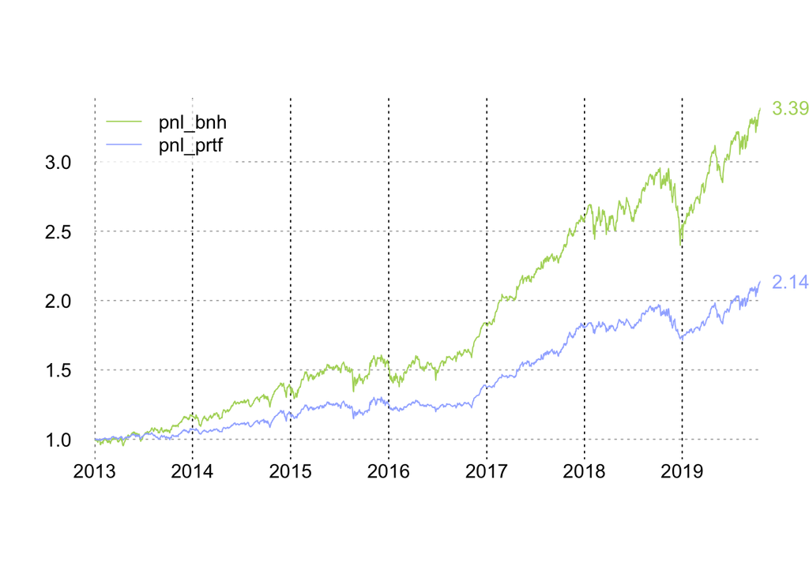

```r
# calc balance
balance = portfolio_result[, .(balance_yeraly = pnl_prtf_yearly[.N]), by = year]
balance[, balance_yeraly := shift( balance_yeraly, fill = 1 ) ]
balance[, balance := cumprod( balance_yeraly )]

# include balance for portf
portfolio_dynamic = merge( portfolio_result, balance, by = "year", all.x = T )
portfolio_dynamic[, pnl_prtf := pnl_prtf_yearly * balance]
portfolio_dynamic[, return_prtf := pnl_prtf/shift(pnl_prtf, fill = 1)-1]

plot_dts( portfolio_dynamic[, .(date,pnl_bnh, pnl_prtf)] )
```

```r
portfolio_dynamic[, calc_perfomance_stat( return_prtf )]
```

```
##     pnl  max_dd mean_dd sharpe
## 1: 1.14 -12.987  -2.311  1.138
```

```r
portfolio_dynamic[, calc_perfomance_stat( return_bnh )]
```

```
##      pnl  max_dd mean_dd sharpe
## 1: 2.387 -18.869  -2.541  1.261
```

### Используем индекс как хедж

В качестве индекса возьмем S&P500, посмотрим на его график и корреляцию с портфелем

```r
# get market data
snp = get_yahoo_data("^GSPC", from = "2012-01-02", to = "2020-01-01")
```

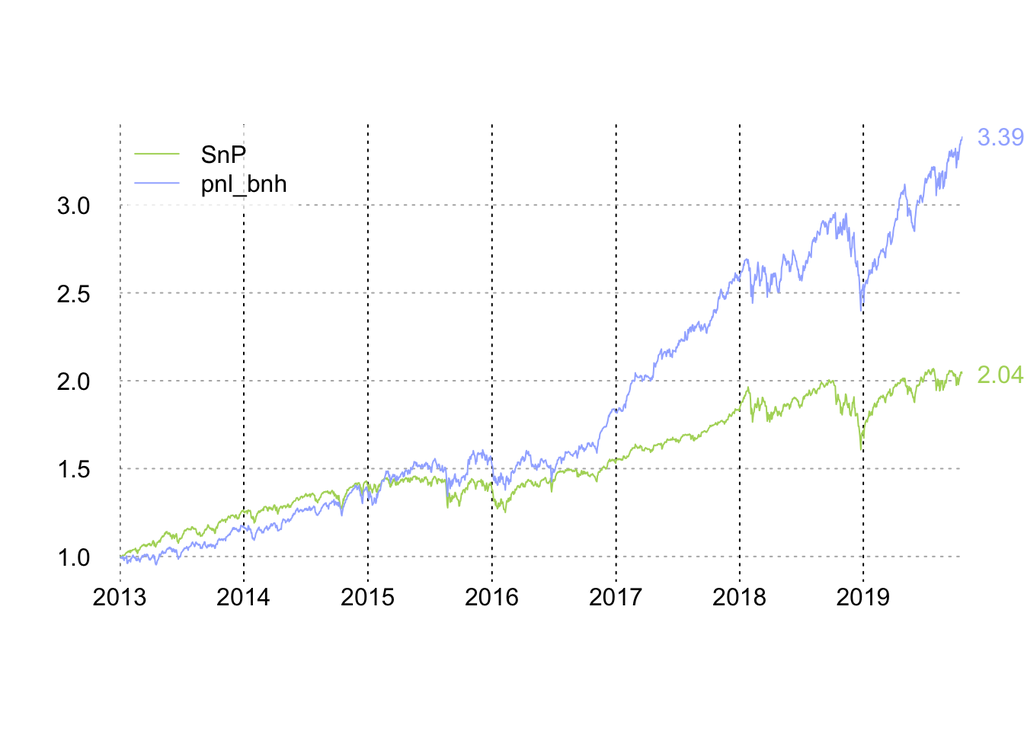

```r
snp = snp[, .(date, close)]

plot_dts(
  snp[date > "2013-01-01", .(date, SnP = close/close[1])],
  portfolio_dynamic[, .(date,pnl_bnh)]
  )
```

```r
snp[, return := close/ shift( close, fill = close[1] ) - 1 ]
cor( snp[date > "2013-01-02"]$return, portfolio_dynamic$return_bnh )
```

```
## [1] 0.8222338
```

Рассчитаем опцион пут для индекса

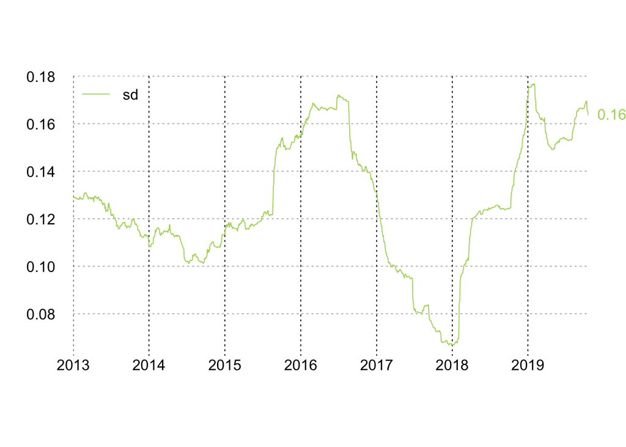

```r
# calc sd and t
snp[, year := year(date)]
snp[, sd := roll_sd( return, 252 ) * sqrt(252)]
snp[, t := as.numeric(date[.N] - date)/365, by = .( year  ) ]
snp = snp[!is.na(sd)]

plot_dts( snp[,.( date, sd )] )
```

```r
snp[, put_price := bsput(close, as.integer(close[1]), sd, 0.01, t, d = 0 ), by = .(  year  ) ]
```

Объединим портфель с путом на индекс  
Чтобы верно посчитать доходность портфеля, нужно привети составляющую доходности бумаг к цене опциона.

```r
# calc portfolio
snp = merge( snp, portfolio_dynamic[, .( date, return_bnh ) ] )

# define portfolio value for each year
snp[, prtf_value := cumprod( return_bnh + 1 ) * close[1], year]

# calc pnl as usual
snp[, pnl_prtf := (prtf_value + put_price ) / (prtf_value[1] + put_price[1]), by = year ]
snp[, return_prtf := pnl_prtf / shift( pnl_prtf, fill = 1 ) - 1, by = year]
```

Посчитаем общий доход портфеля

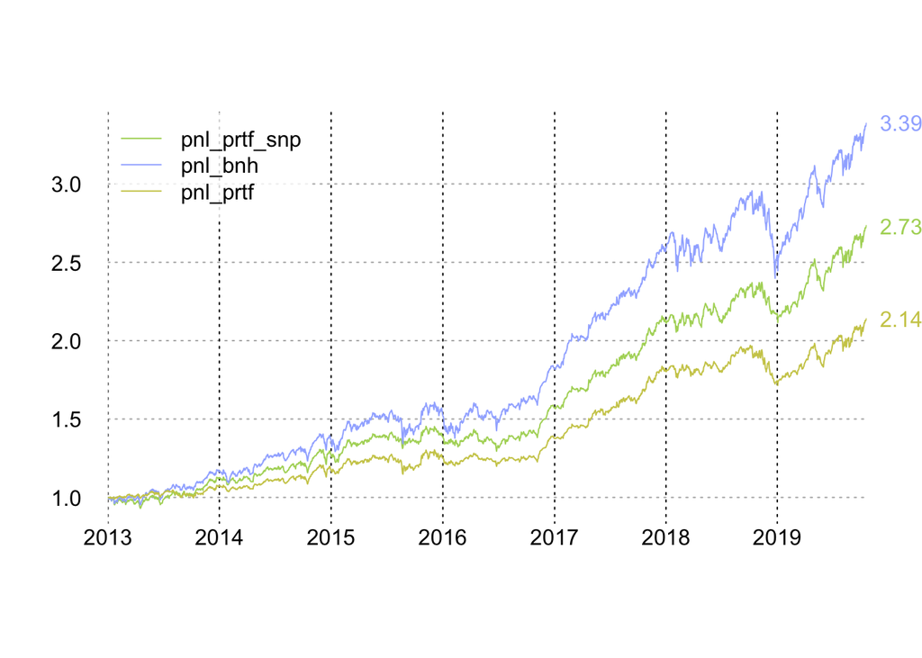

```r
snp[, pnl_prtf_yearly := cumprod(return_prtf+1), year]


# calc balance
balance = snp[, .(balance_yeraly = pnl_prtf_yearly[.N]), by = year]
balance[, balance_yeraly := shift( balance_yeraly, fill = 1 ) ]
balance[, balance := cumprod( balance_yeraly )]

# include balance for portf
snp = merge( snp, balance, by = "year", all.x = T )
snp[, pnl_prtf := pnl_prtf_yearly * balance]
snp[, return_prtf := pnl_prtf/shift(pnl_prtf, fill = 1)-1]

plot_dts(
  snp[, .(date, pnl_prtf_snp = pnl_prtf)],
  portfolio_dynamic[, .(date,pnl_bnh, pnl_prtf)]
)
```

Сравним результаты

```r
result = rbind(
portfolio_dynamic[, calc_perfomance_stat( return_bnh )],
portfolio_dynamic[, calc_perfomance_stat( return_prtf )],
snp[, calc_perfomance_stat( return_prtf ) ]
)

result$name = c( "buy and hold", "stock put", "S&P put" )

result[order(-sharpe)]
```

```
##      pnl  max_dd mean_dd sharpe         name
## 1: 1.734 -10.929  -2.276  1.326      S&P put
## 2: 2.387 -18.869  -2.541  1.261 buy and hold
## 3: 1.140 -12.987  -2.311  1.138    stock put
```

### ДЗ

1. Сделать портфель из одной бумаги и опциона. Посмотреть два варианта для call и put.  
   Сравнить результаты и понять почему отличаются. В каких случаях можно использовать тот или иной тип опциона
2. Выбрать три актива и собрать из них три портфеля:  
   Buy&Hold, хеджирование путом для каждой бумаги и с путом по индексу.
3. В портфели с путом по индексу сравнить разные варианты страйков пута: 100%, 95% и 90%.  
   Почему отличается общая доходность портфеля во всех трех случаях?  
   В опционах принято обозначть покупку/продажу опциона по отношщению к цене актива.  
   100% страйк (или просто 100 страйк) - покупка/продажа опциона со страйком, равным цене актива  
   105% страйк (или просто 105 страйк) - покупка/продажа опциона со страйком выше на 5% от цены актива  
   95% страйк (или просто 95 страйк) - покупка/продажа опциона со страйком ниже на 5% от цены актива  
   и по аналогии